# Red Wine Dataset Exploration by Raj Dayal Natarajan

#### Alcohol content impact on quality of wine

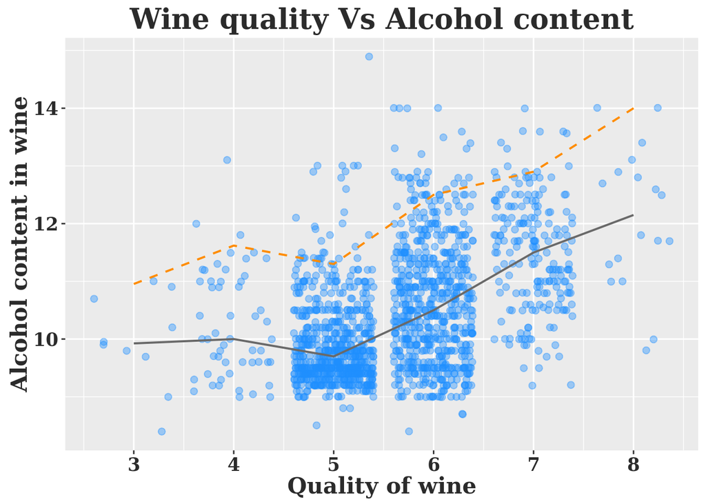

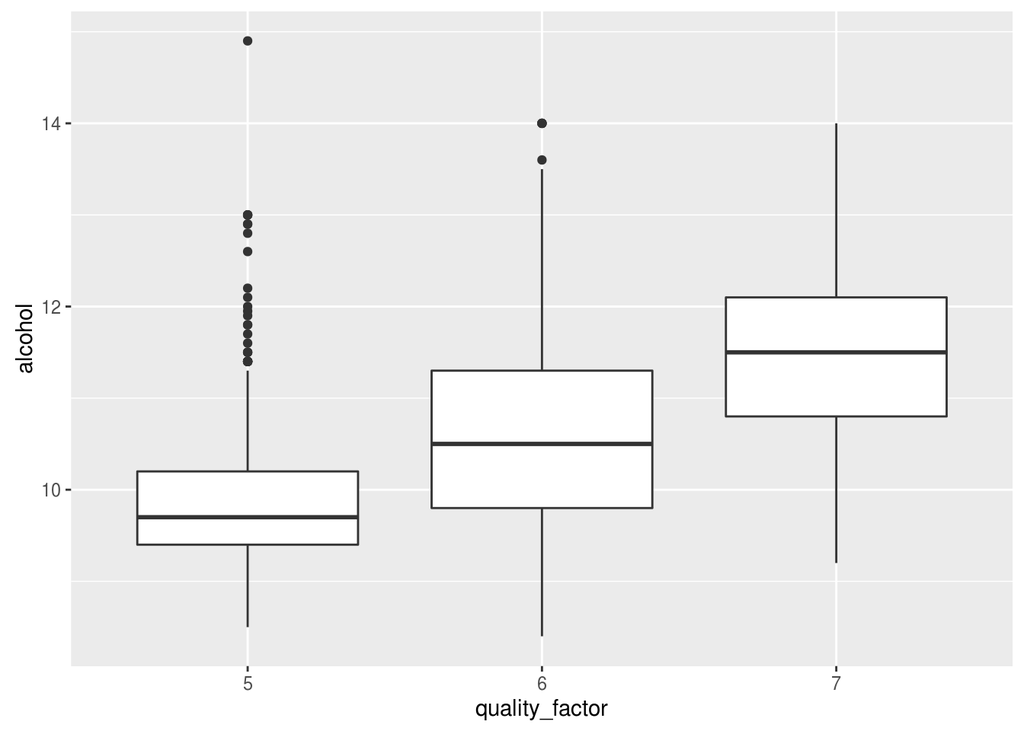

The below plot constructs a histogram of the alcohol content across different wine quality. The color in the chart adds the second dimension to the plot. It can be seen from the chart the as the quality of the wine improves the alcohol content distributions are displaced to the right, showing the increase in alcohol content increases as the quality of the wine improves.

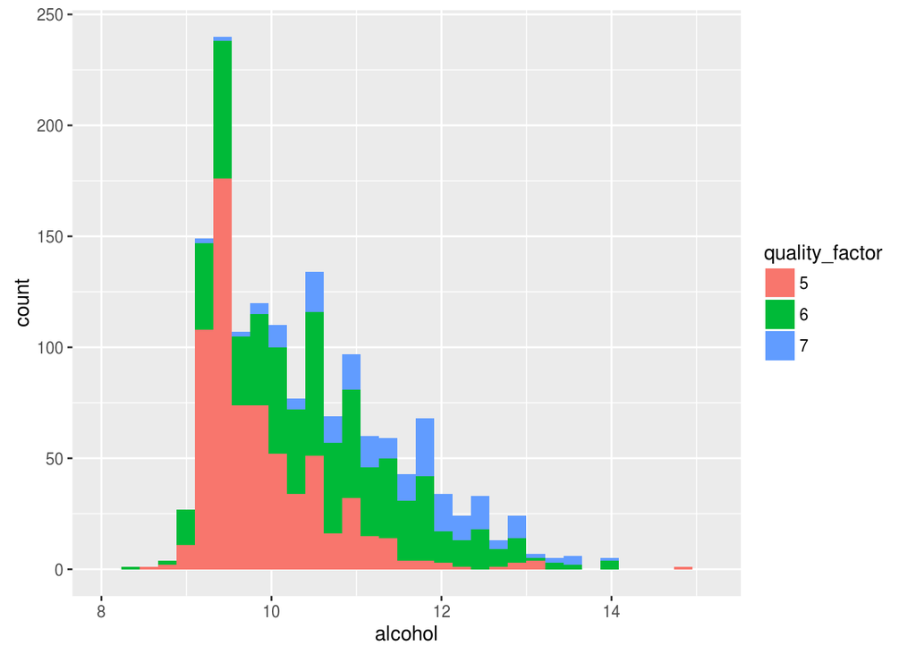

[figure not shown]

```r
ggplot(aes(x = alcohol, fill = quality_factor),
       data = subset(Reds,quality == 5 |quality ==6 |quality ==7)) +
  geom_histogram()
```

#### Understanding the pH of wines:

This section explores the other variables (other than quality) which are of interest.

I know from basic chemistry that pH is an indication of alkalinity or acidity. I want to confirm this relationship on the wine dataset. The below chart plots the pH value against the citric acid content and fixed acidity content in the wines.

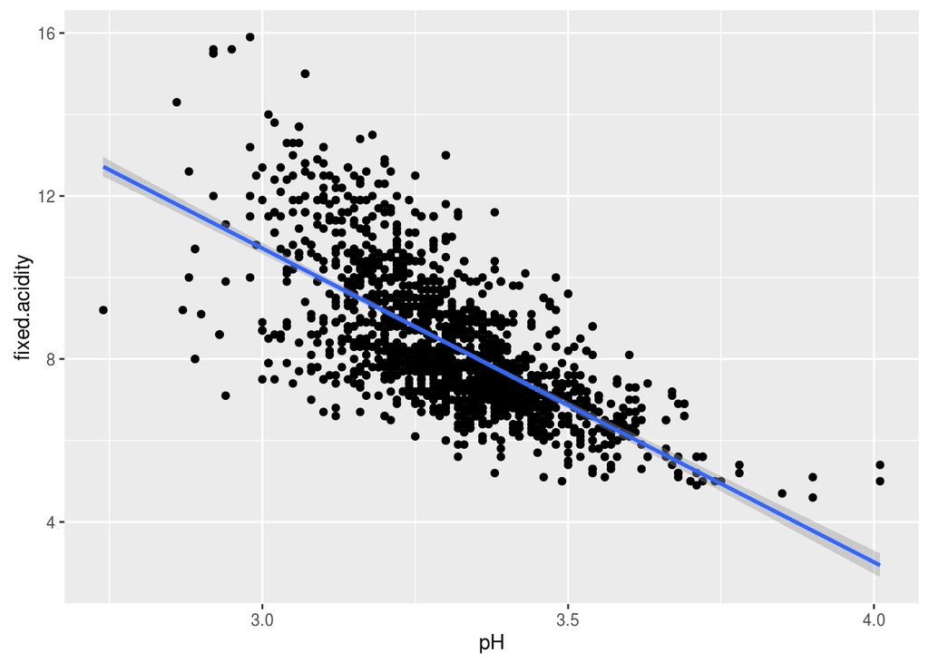

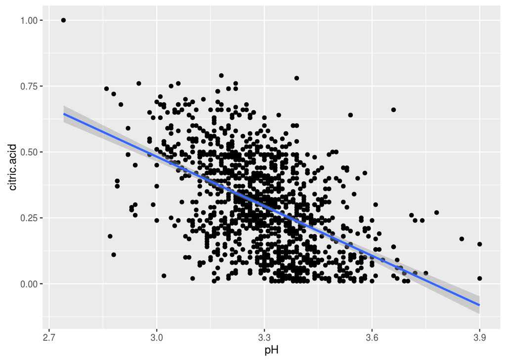

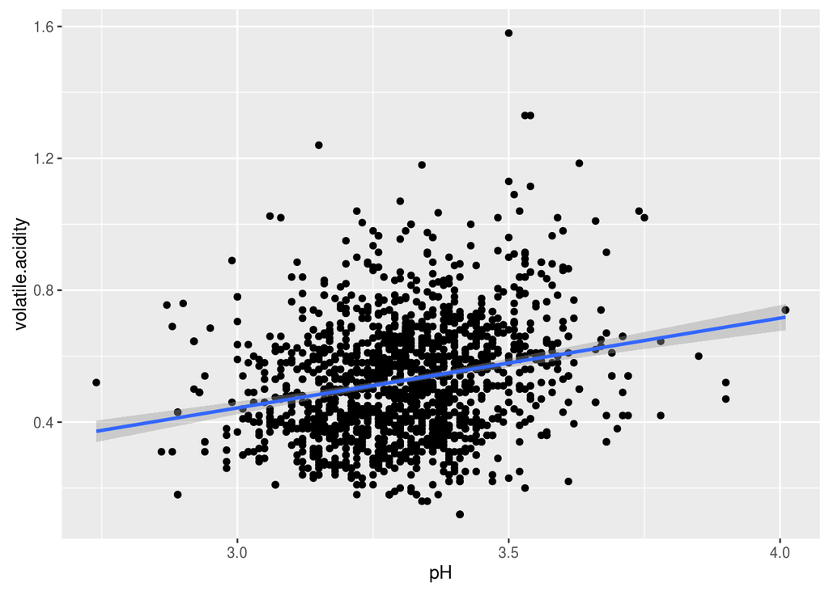

#### Understanding the cause of density in wines:

Since the density is clustered in the range of 990 to 1000, I thought that plotting a transformed density made more sense. Hence I have plotted the density as 1000-density from the dataset.

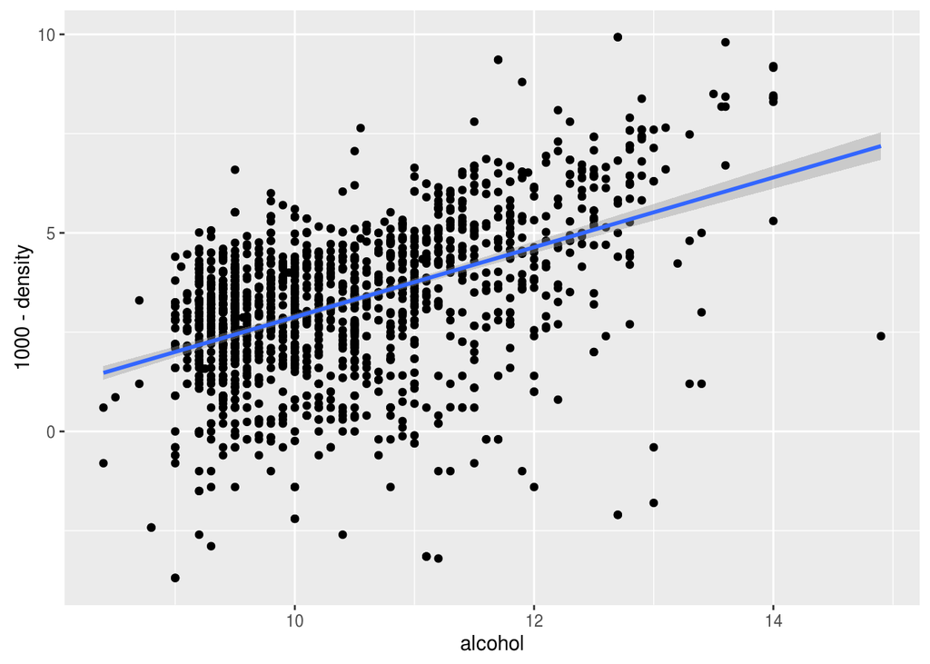

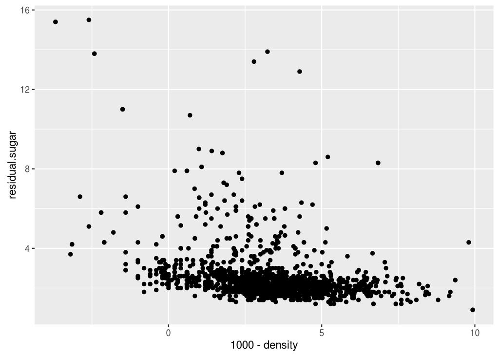

# Bivariate Analysis

### Talk about some of the relationships you observed in this part of the investigation. How did the feature(s) of interest vary with other features in the dataset?

#### Citric acid effect on quality

I was wondering whether the citic acid will have an effect on quality. Do the wine experts think that freshness is desired in wines? Based on the box plot above, it does look like that the freshness of the citric acid does have an positive impact on the taste of the wine.

#### Alcohol content impact on quality

It also seems like increasing the alcohol content in the wines, improves the sensory perception of the wines, basedon the given dataset.

### Did you observe any interesting relationships between the other features (not the main feature(s) of interest)?

There was one relationship which was a surprise - the positive correlation between pH and volatile acidity, even though the correlation seems low. However, the other measures of acidity move as expected with pH. They have a negative correlation as seen on the charts and as expected.

### What was the strongest relationship you found?

The strongest relationship for the factor of interest (quality) was with the alcohol content with a correlation co-efficient of 0.476.

# Multivariate Plots Section

#### Relationship between acidity and pH

```
##
##  Pearson's product-moment correlation
##
## data:  Reds$pH and Reds$volatile.acidity
## t = 9.659, df = 1597, p-value < 2.2e-16
## alternative hypothesis: true correlation is not equal to 0
## 95 percent confidence interval:
##  0.1880823 0.2807254
## sample estimates:
##       cor
## 0.2349373
```

```
##
##  Pearson's product-moment correlation
##
## data:  Reds$pH and Reds$fixed.acidity
## t = -37.366, df = 1597, p-value < 2.2e-16
## alternative hypothesis: true correlation is not equal to 0
## 95 percent confidence interval:
##  -0.7082857 -0.6559174
## sample estimates:
##        cor
## -0.6829782
```

```
##
##  Pearson's product-moment correlation
##
## data:  Reds$pH and Reds$citric.acid
## t = -25.767, df = 1597, p-value < 2.2e-16
## alternative hypothesis: true correlation is not equal to 0
## 95 percent confidence interval:
##  -0.5756337 -0.5063336
## sample estimates:
##        cor
## -0.5419041
```

```
##
##  Pearson's product-moment correlation
##
## data:  Reds$citric.acid and Reds$fixed.acidity
## t = 36.234, df = 1597, p-value < 2.2e-16
## alternative hypothesis: true correlation is not equal to 0
## 95 percent confidence interval:
##  0.6438839 0.6977493
## sample estimates:
##       cor
## 0.6717034
```

```
##
##  Pearson's product-moment correlation
##
## data:  Reds$fixed.acidity and Reds$volatile.acidity
## t = -10.589, df = 1597, p-value < 2.2e-16
## alternative hypothesis: true correlation is not equal to 0
## 95 percent confidence interval:
##  -0.3013681 -0.2097433
## sample estimates:
##        cor
## -0.2561309
```

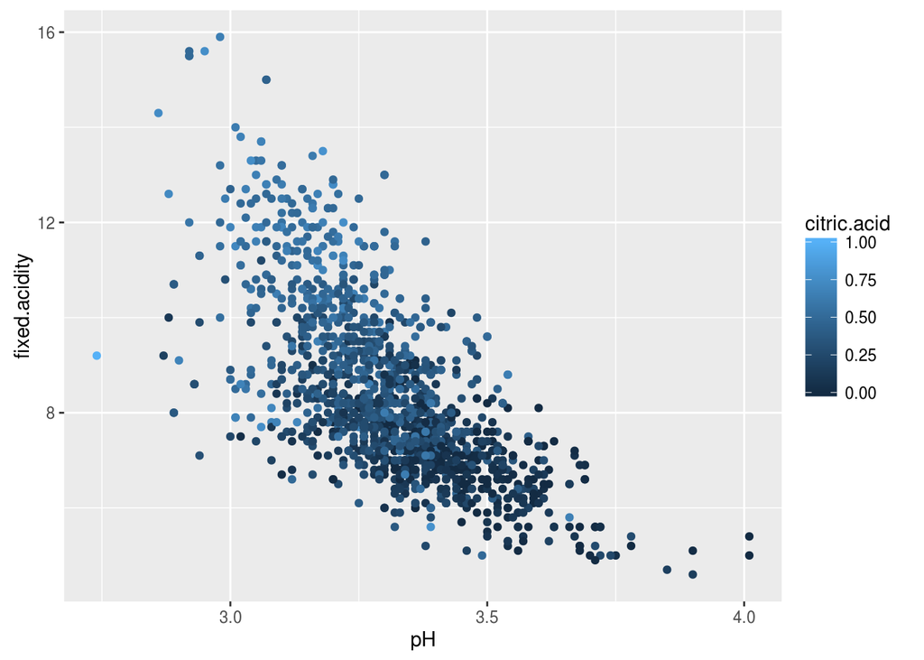

#### Relationship between density, sugar content and alcohol

```
##
##  Pearson's product-moment correlation
##
## data:  Reds$density and Reds$alcohol
## t = -22.838, df = 1597, p-value < 2.2e-16
## alternative hypothesis: true correlation is not equal to 0
## 95 percent confidence interval:
##  -0.5322547 -0.4583061
## sample estimates:
##        cor
## -0.4961798
```

```
##
##  Pearson's product-moment correlation
##
## data:  Reds$density and Reds$residual.sugar
## t = 15.189, df = 1597, p-value < 2.2e-16
## alternative hypothesis: true correlation is not equal to 0
## 95 percent confidence interval:
##  0.3116908 0.3973835
## sample estimates:
##       cor
## 0.3552834
```

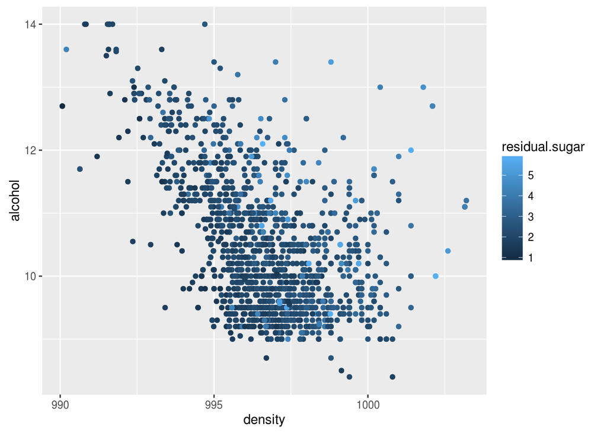

```
## Reds$quality: 3
##    Min. 1st Qu.  Median    Mean 3rd Qu.    Max.
##     3.0     5.0     6.0    11.0    14.5    34.0
## --------------------------------------------------------
## Reds$quality: 4
##    Min. 1st Qu.  Median    Mean 3rd Qu.    Max.
##    3.00    6.00   11.00   12.26   15.00   41.00
## --------------------------------------------------------
## Reds$quality: 5
##    Min. 1st Qu.  Median    Mean 3rd Qu.    Max.
##    3.00    9.00   15.00   16.98   23.00   68.00
## --------------------------------------------------------
## Reds$quality: 6
##    Min. 1st Qu.  Median    Mean 3rd Qu.    Max.
##    1.00    8.00   14.00   15.71   21.00   72.00
## --------------------------------------------------------
## Reds$quality: 7
##    Min. 1st Qu.  Median    Mean 3rd Qu.    Max.
##    3.00    6.00   11.00   14.05   18.00   54.00
## --------------------------------------------------------
## Reds$quality: 8
##    Min. 1st Qu.  Median    Mean 3rd Qu.    Max.
##    3.00    6.00    7.50   13.28   16.50   42.00
```

```
## Reds$quality: 3
##    Min. 1st Qu.  Median    Mean 3rd Qu.    Max.
##  0.4000  0.5125  0.5450  0.5700  0.6150  0.8600
## --------------------------------------------------------
## Reds$quality: 4
##    Min. 1st Qu.  Median    Mean 3rd Qu.    Max.
##  0.3300  0.4900  0.5600  0.5964  0.6000  2.0000
## --------------------------------------------------------
## Reds$quality: 5
##    Min. 1st Qu.  Median    Mean 3rd Qu.    Max.
##   0.370   0.530   0.580   0.621   0.660   1.980
## --------------------------------------------------------
## Reds$quality: 6
##    Min. 1st Qu.  Median    Mean 3rd Qu.    Max.
##  0.4000  0.5800  0.6400  0.6753  0.7500  1.9500
## --------------------------------------------------------
## Reds$quality: 7
##    Min. 1st Qu.  Median    Mean 3rd Qu.    Max.
##  0.3900  0.6500  0.7400  0.7413  0.8300  1.3600
## --------------------------------------------------------
## Reds$quality: 8
##    Min. 1st Qu.  Median    Mean 3rd Qu.    Max.
##  0.6300  0.6900  0.7400  0.7678  0.8200  1.1000
```

# Multivariate Analysis

### Talk about some of the relationships you observed in this part of the investigation. Were there features that strengthened each other in terms of looking at your feature(s) of interest?

#### Interaction between pH, citric acid and fixed acidity

The ‘Relationship between acidity and pH’ graph, captures the essence of the data from the correlation. It can be seen that there pH becomes markedly acidic as we move toward higher concentrations of fixed acidity (tartaric acid) and citic acid in the wine. The correlation between the fixed acidity and the citric acid can also be gleaned from the chart, if the color dimension is taken into account.

#### Relationship between density, alcohol content and sugar levels

This graph did not give me that much of an insight into the three variable relationship. Since most of the datapoints have sugar levels which are in the range of 1 to 6, I have subsett the data to wines having sugar levels below 6.

### Were there any interesting or surprising interactions between features?

### OPTIONAL: Did you create any models with your dataset? Discuss the strengths and limitations of your model.

Sampling:

First, I divided the data to create a training set and a test set. The tarining set has 1146 observations and the test set has 371 observations.

All the parameters in the original Red Wine dataset was used as features to predict the quality of wine. The parameters ‘quality’ and ‘Serial’ were removed from the feature set as one was the predicted variable(quality) and ‘Serial’ was deemed irrelevant obviously.

Model iterations:

When iterating the model, I found certain variables to be highly correlated and removing one of them improved the accuracy of the model. In specific, the fixed acidity and citric acid content in the wines were highly correlated. Removing the fixed acidity from the feature set bumped up the accuracy by 2%

Results:

Initially I used the SVM model with a ‘radial’ kernel. The model was fitted and prediction was done on the test daat set, the accuracy of prediction was 65.2%.

The sigmoid and the polynomial kernels fard much worse with predicting the quality. However, the linear model gave a much better fit, with an accuracy of 69% for predicting the quality of the wine.

On plotting the Delta between the actual quality and the predicted quality, it was found that majority of the points fall within a variation of ‘1’ in terms of the quality metric.

Strengths and weaknesses:

The model has a pretty good accuracy in classifying the wines - Accuracy at 70%. However, I believe that it can be tweaked to improve the scores.

Further work, can be done by playing around with the Cost, Gamma variables to tune it.

```
##
## Calls:
## m1: lm(formula = I(quality) ~ I(alcohol), data = Reds)
## m2: lm(formula = I(quality) ~ I(alcohol) + volatile.acidity, data = Reds)
## m3: lm(formula = I(quality) ~ I(alcohol) + citric.acid, data = Reds)
##
## =====================================================
##                        m1         m2         m3
## -----------------------------------------------------
##   (Intercept)        1.875***   3.095***   1.830***
##                     (0.175)    (0.184)    (0.171)
##   I(alcohol)         0.361***   0.314***   0.346***
##                     (0.017)    (0.016)    (0.016)
##   volatile.acidity             -1.384***
##                                (0.095)
##   citric.acid                              0.730***
##                                           (0.090)
## -----------------------------------------------------
##   R-squared              0.2        0.3        0.3
##   adj. R-squared         0.2        0.3        0.3
##   sigma                  0.7        0.7        0.7
##   F                    468.3      370.4      276.6
##   p                      0.0        0.0        0.0
##   Log-likelihood     -1721.1    -1621.8    -1688.7
##   Deviance             805.9      711.8      773.9
##   AIC                 3448.1     3251.6     3385.4
##   BIC                 3464.2     3273.1     3406.9
##   N                   1599       1599       1599
## =====================================================
```

```
##
## Call:
## svm.default(x = x, y = y, kernel = "linear")
##
##
## Parameters:
##    SVM-Type:  eps-regression
##  SVM-Kernel:  linear
##        cost:  1
##       gamma:  0.1
##     epsilon:  0.1
##
##
## Number of Support Vectors:  1024
```

```
## [1] 0.690027
```

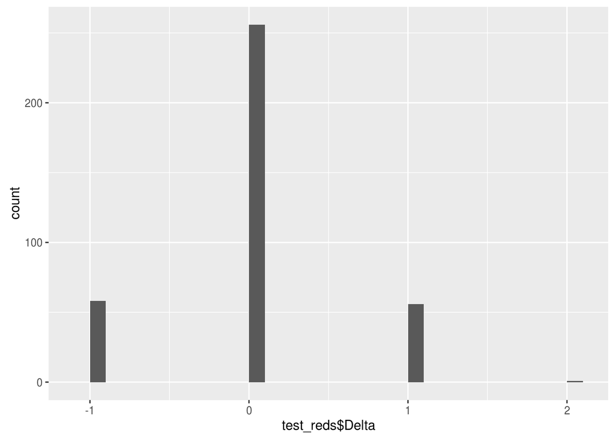

# Final Plots and Summary

### Plot One

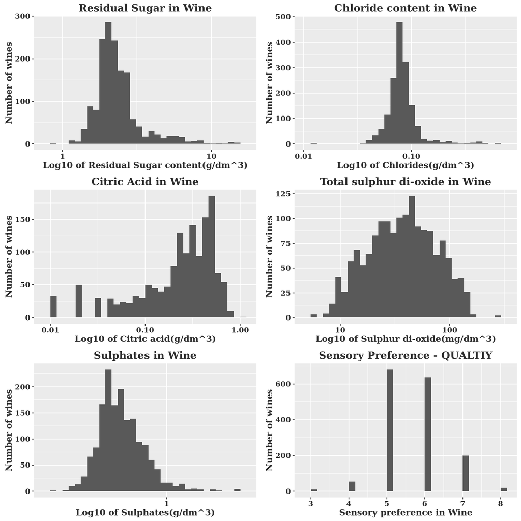

### Description One

In addition to the quality factor, I have also plotted other variables, which initially had a very long tailed distribution by transforming them to a log scale. As it can be seen, most of them transform well to almost a normal distribution.

### Plot Two

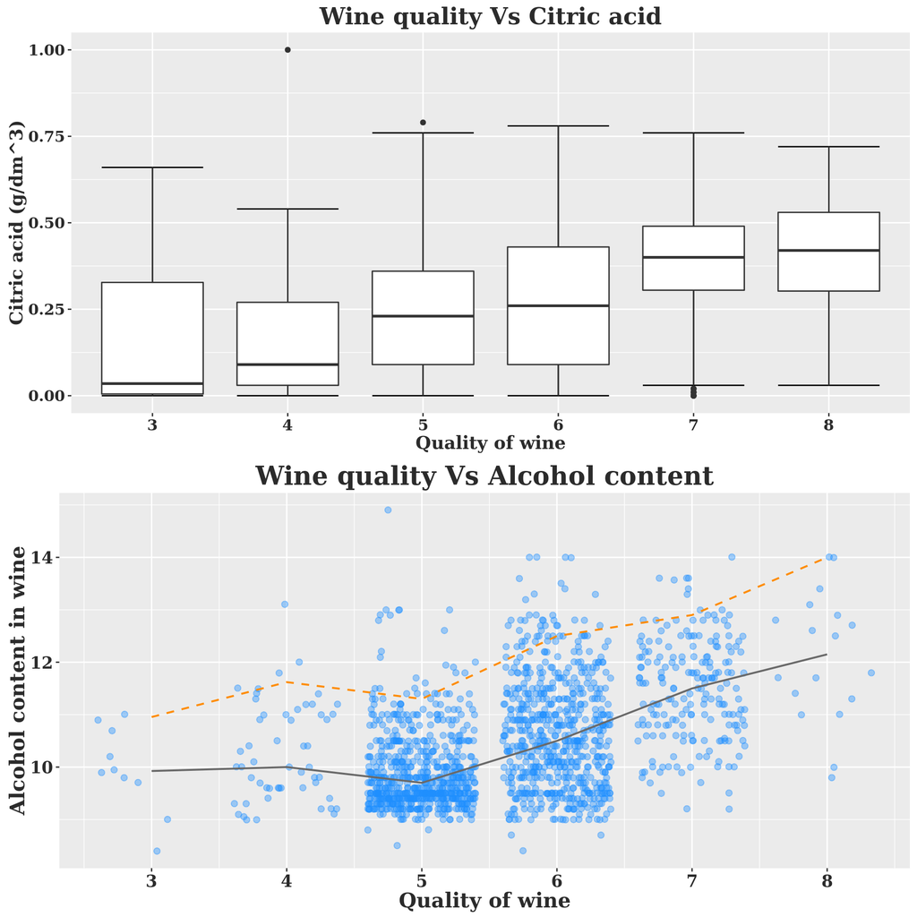

### Plot Three

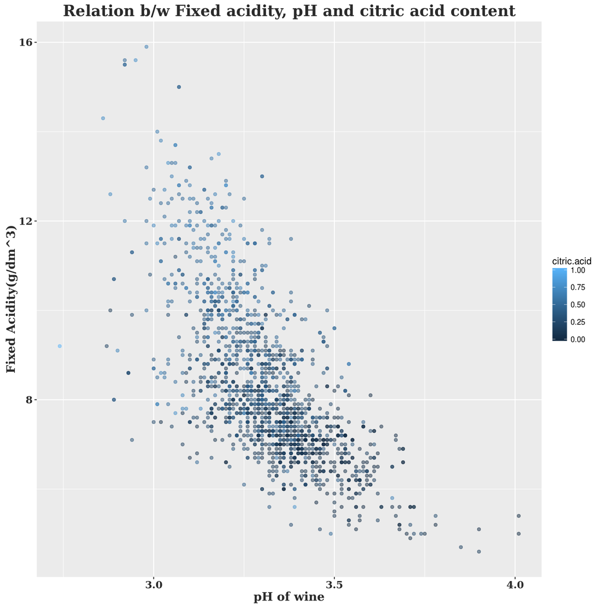

### Description Three

This chart captures the essence of the realtionship between three variables - pH, Fixed acidity and citric acid content.

We know that pH should be inversly correlated with acidity, which is shown by the plot.

In addition, we we would expect that citric acid will increase the acidity in the wine. This is demonstrated by the chart if look at the color gradient of the points in relation to the fixed acidity scale. We see that the two variables they move up and down together.

# Reflection

The red wine dataset contains 13 variables (Including a serial id of the obervations) and 1599 observations for the dataset. One thing which pops out, is that there are no categorical variables. The variables are either discrete or continuous. The quality of the wine is the only variable which can be treated like a categorical or a discrete variable. The most interesting variable is the quality or the sensory perception of the wine. This variable in the dataset ranks the wine quality from low to high as we go from 1 to 8. However, the majority of the wines in the dataset have been classified as 5,6 or7. This poses some level of difficulty when finding correlation between quality and the rest of the variables which happen to be continuous.Regardless, we do see some variable do tend to show correlation to the quality of wines.These are alcohol content, volatile acidity content(negative correlation), citric acid content and the amount of sulphates in the wine.

In addition, I found some interesting relationships and correlations from the dataset among other variables. For example, there is a negative correlation between pH values and the fixed acidity content in the wine and a postive correlation between fixed acidity and citric acid content.

Struggles:

Future work:

One way to gain a better understanding of how the features drive the wine quality would be to use principal component analysis to understand which features are critical in determining the wine quality. Even though the current SVM model has a good accuracy of around 70%, I believe, using PCA (Principal component analysis) will result in a better understanding and modeling of the dataset.